# Practical 3 Repeated Measurements

## Practical 3: Marginal Models for Discrete Data

We start by loading the packages we will need for this practical and the data from [GitHub](https://github.com/drizopoulos/Repeated_Measurements). This is achieved with the following commands:

```r
# packages
library("lattice")
library("geepack")
library("splines")

# data
con <- url("https://raw.github.com/drizopoulos/Repeated_Measurements/master/Data.RData")
load(con)
close(con)
```

### Question 1

The following piece of code creates the dummy variable for abnormal prothrombin time:

```r
pbc2$Dicht_prothro <- as.numeric(with(pbc2, prothrombin < 11 | prothrombin > 13))
```

### Question 2

To examine graphically the shape of the probability of abnormal prothrombin time we can smooth the scatterplot of the `Dicht_prothro`. Using function [xyplot()](https://goo.gl/cGSjZk) as in previous practicals, we first create the scatterplot of `Dicht_prothro` versus follow-up time, separately for placebo and D-penicillamine patients, and we include the loess curve:

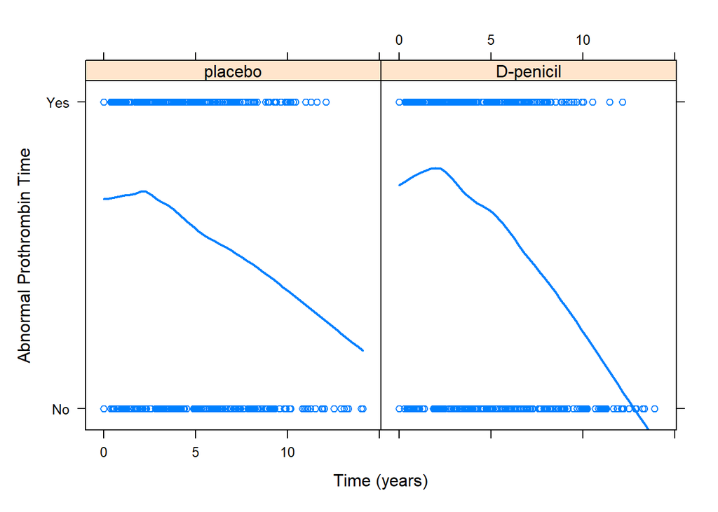

```r
xyplot(Dicht_prothro ~ year | drug, data = pbc2,
       type = c("p", "smooth"), lwd = 2,
       xlab = "Time (years)", ylab = "Abnormal Prothrombin Time",
       scales = list(y = list(at = 0:1, labels = c("No", "Yes"))))
```

Note that due to the binary nature of `Dicht_prothro`, the actual data points do not provide any useful information. However, the loess smoother can still be used and recover the shape of the probability of abnormal prothrombin time (**note:** the probability of abnormal prothrombin time is actually the sample mean of the `Dicht_prothro` variable). For both treatment groups we observe a decrease in the probability of abnormal prothrombin time during follow-up. We continue by producing the same plot but now splitting the panels for males and females:

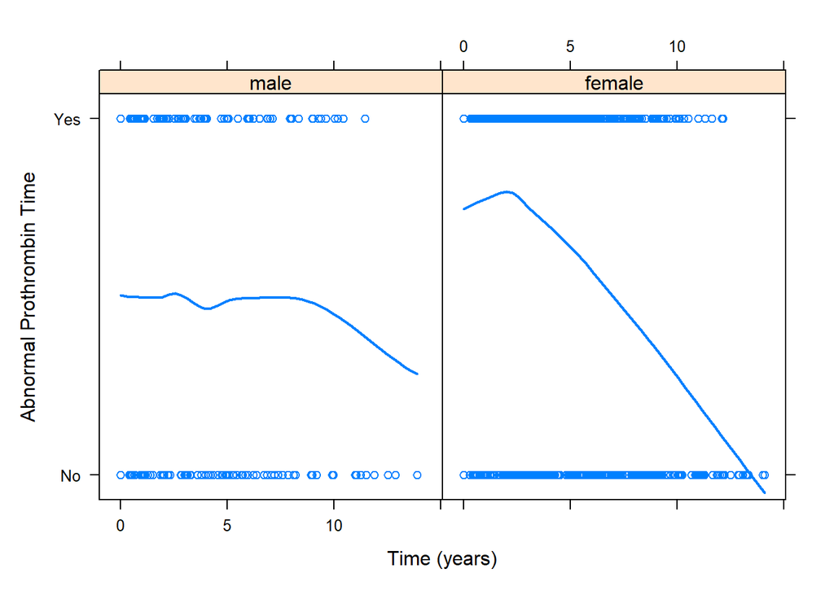

```r
xyplot(Dicht_prothro ~ year | sex, data = pbc2,
       type = c("p", "smooth"), lwd = 2,
       xlab = "Time (years)", ylab = "Abnormal Prothrombin Time",
       scales = list(y = list(at = 0:1, labels = c("No", "Yes"))))
```

This figure suggests that males have more stable evolutions, and that actually the females are the ones who improve over time. Note that at this stage this is just an observation from just looking at the data. To make a formal conclusion we will need to test this conjecture. We finally produce the same scatterplot and we split at different age categories, namely, [25, 43], [43, 50], [50, 55], and [55, 80]. To achieve this we use function [cut()](https://goo.gl/t8xP1d), i.e.,

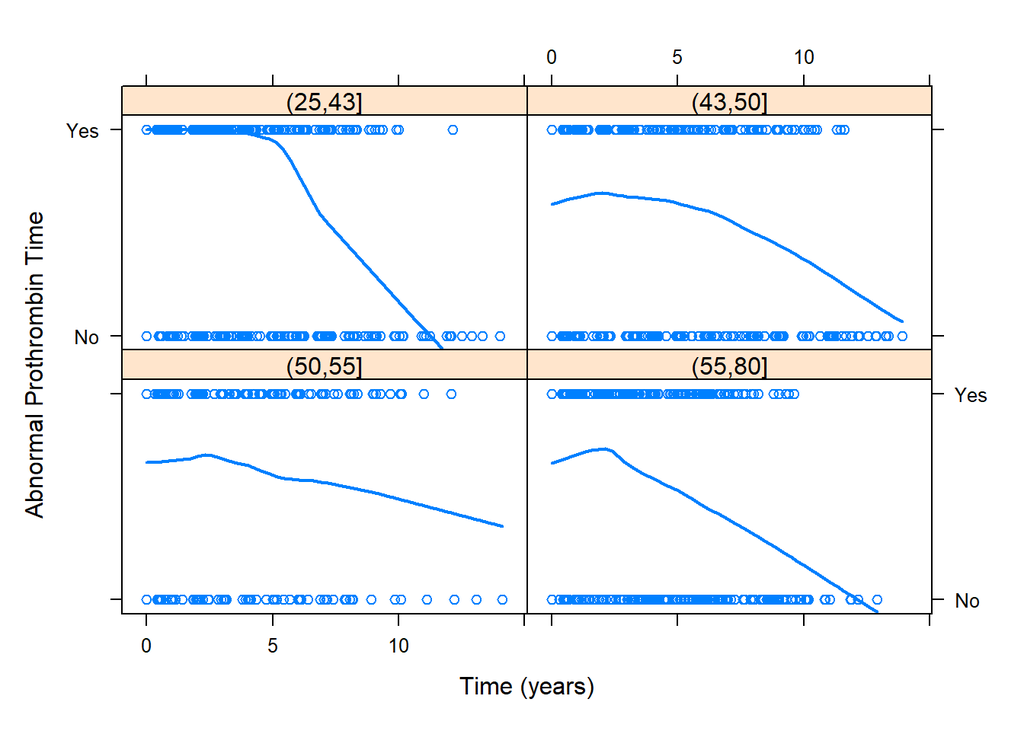

```r
xyplot(Dicht_prothro ~ year | cut(age, c(25, 43, 50, 55, 80)), data = pbc2,
       type = c("p", "smooth"), lwd = 2, as.table = TRUE,
       xlab = "Time (years)", ylab = "Abnormal Prothrombin Time",
       scales = list(y = list(at = 0:1, labels = c("No", "Yes"))))
```

We observe some subtle difference in the evolutions of the different age categories.

### Question 3

Based on the description of Question 3, we need to fit a GEE model with an exchangeable working correlation matrix, and include in the mean structure the nonlinear effect of time using natural cubic splines with 2 degrees of freedom (i.e., using function [ns()](https://goo.gl/zeAjzF)), the interaction of this nonlinear effect with drug and sex (while also including the main effects of these variables), the main effect of age, and its interaction with sex. This model is fitted with following call to function [geeglm()](https://goo.gl/1S1uix) (**note:** we also need to set the `family` argument to `binomial()`, and supply the `id` argument to identify the clusters, i.e., in this case the patients):

```r
fm_1 <- geeglm(Dicht_prothro ~ ns(year, 2, B = c(0, 9.3)) * (drug + sex) + age + age:sex,
               family = binomial(), data = pbc2, id = id, corstr = "exchangeable")

summary(fm_1)
```

```
##
## Call:
## geeglm(formula = Dicht_prothro ~ ns(year, 2, B = c(0, 9.3)) *
##     (drug + sex) + age + age:sex, family = binomial(), data = pbc2,
##     id = id, corstr = "exchangeable")
##
##  Coefficients:
##                                            Estimate   Std.err   Wald Pr(>|W|)
## (Intercept)                                0.686898  0.981014  0.490 0.483808
## ns(year, 2, B = c(0, 9.3))1               -0.257298  0.906351  0.081 0.776500
## ns(year, 2, B = c(0, 9.3))2                0.209986  0.502682  0.174 0.676143
## drugD-penicil                              0.130014  0.232186  0.314 0.575510
## sexfemale                                  0.642015  1.047406  0.376 0.539905
## age                                       -0.013024  0.016199  0.646 0.421401
## ns(year, 2, B = c(0, 9.3))1:drugD-penicil  0.308790  0.637579  0.235 0.628161
## ns(year, 2, B = c(0, 9.3))2:drugD-penicil -0.863341  0.407950  4.479 0.034320
## ns(year, 2, B = c(0, 9.3))1:sexfemale     -0.679060  0.885719  0.588 0.443274
## ns(year, 2, B = c(0, 9.3))2:sexfemale     -1.699558  0.486083 12.225 0.000472
## sexfemale:age                              0.001183  0.018114  0.004 0.947944
##
## (Intercept)
## ns(year, 2, B = c(0, 9.3))1
## ns(year, 2, B = c(0, 9.3))2
## drugD-penicil
## sexfemale
## age
## ns(year, 2, B = c(0, 9.3))1:drugD-penicil
## ns(year, 2, B = c(0, 9.3))2:drugD-penicil *
## ns(year, 2, B = c(0, 9.3))1:sexfemale
## ns(year, 2, B = c(0, 9.3))2:sexfemale     ***
## sexfemale:age
## ---
## Signif. codes:  0 '***' 0.001 '**' 0.01 '*' 0.05 '.' 0.1 ' ' 1
##
## Correlation structure = exchangeable
## Estimated Scale Parameters:
##
##             Estimate Std.err
## (Intercept)    1.003  0.0366
##   Link = identity
##
## Estimated Correlation Parameters:
##       Estimate Std.err
## alpha   0.1751 0.02287
## Number of clusters:   312  Maximum cluster size: 16
```

The `summary()` function produces a detailed output of the fitted model, with the parameter estimates, standard errors and corresponding p-values.

### Question 4

We continue the analysis by re-fitting the model of Question 3 with the independence and auto-regressive of order 1 working correlation matrices. This is done with the following call to [geeglm()](https://goo.gl/1S1uix) by suitably changing the `corstr` argument:

```r
fm_2 <- geeglm(Dicht_prothro ~ ns(year, 2, B = c(0, 9.3)) * (drug + sex) + age + age:sex,
               family = binomial(), data = pbc2, id = id, corstr = "independence")

fm_3 <- geeglm(Dicht_prothro ~ ns(year, 2, B = c(0, 9.3)) * (drug + sex) + age + age:sex,
               family = binomial(), data = pbc2, id = id, corstr = "ar1")
```

We collect the estimated coefficients the two types of standard errors (i.e., sandwich and naive) using similar code as in Section 4.5

```r
# parameters
betas <- cbind("independence" = coef(fm_2),
            "exchangeable" = coef(fm_1),
            "AR1" = coef(fm_3))

# Sandwich standard errors
extractSEs <- function (model) sqrt(diag(model$geese$vbeta))
ses_sand <- cbind("independence" = extractSEs(fm_2),
            "exchangeable" = extractSEs(fm_1),
            "AR1" = extractSEs(fm_3))

# Naive standard errors
extractSEs_naive <- function (model) sqrt(diag(model$geese$vbeta.naiv))
ses_naiv <- cbind("independence" = extractSEs_naive(fm_2),
            "exchangeable" = extractSEs_naive(fm_1),
            "AR1" = extractSEs_naive(fm_3))
```

To make the coefficients’ plot, we put the estimates and the calculated confidence intervals (both naive and robust) in a data frame:

```r
dat <- data.frame(
    est = c(betas),
    lower_sand = unname(c(betas) - 1.96 * c(ses_sand)),
    lower_naiv = unname(c(betas) - 1.96 * c(ses_naiv)),
    upper_sand = unname(c(betas) + 1.96 * c(ses_sand)),
    upper_naiv = unname(c(betas) + 1.96 * c(ses_naiv)),
    parm = gl(11, 1, 33, labels = rownames(betas)),
    work_corr = gl(3, 11, labels = colnames(betas))
)
```

To produce the plot, we first define the `prepanel.ci2()` and `panel.ci2()` functions:

```r
prepanel.ci2 <- function (x, y, lx, ux, lx2, ux2, subscripts, ...) {
    x <- as.numeric(x)
    lx <- as.numeric(lx[subscripts])
    ux <- as.numeric(ux[subscripts])
    lx2 <- as.numeric(lx2[subscripts])
    ux2 <- as.numeric(ux2[subscripts])
    list(xlim = range(x, ux, lx, ux2, lx2, finite = TRUE))
}
panel.ci2 <- function (x, y, lx, ux, lx2, ux2, subscripts, pch = 16, ...) {
    x <- as.numeric(x)
    y <- as.numeric(y)
    lx <- as.numeric(lx[subscripts])
    ux <- as.numeric(ux[subscripts])
    lx2 <- as.numeric(lx2[subscripts])
    ux2 <- as.numeric(ux2[subscripts])
    panel.abline(h = c(unique(y)),
                 col = "grey", lty = 2, lwd = 1.5)
    panel.arrows(lx, y, ux, y,
                 length = 0.1, unit = "native",
                 angle = 90, code = 3, lwd = 2, col = "blue")
    panel.arrows(lx2, y + 0.08, ux2, y + 0.08,
                 length = 0.1, unit = "native",
                 angle = 90, code = 3, lwd = 2, col = "magenta2")
    panel.xyplot(x, y, pch = pch, col = 2, cex = 0.9, ...)
    panel.xyplot(x, y + 0.08, pch = pch, col = 2, cex = 0.9, ...)
}
```

And following we call [dotplot()](https://goo.gl/7w7nrR):

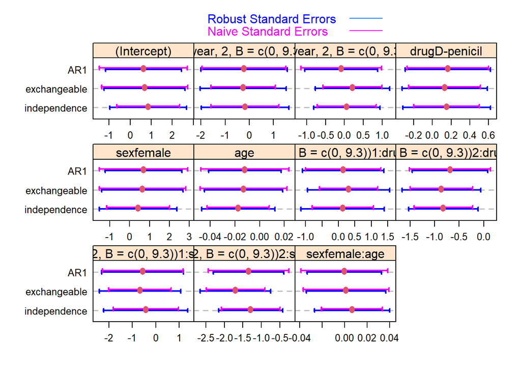

```r
dotplot(work_corr ~  est | parm, lx = dat$lower_sand, lx2 = dat$lower_naiv,
        ux = dat$upper_sand, ux2 = dat$upper_naiv,
        data = dat, xlab = "", prepanel = prepanel.ci2, panel = panel.ci2,
        as.table = TRUE, scales = list(x = list(relation = "free")),
        key = simpleKey(c("Robust Standard Errors", "Naive Standard Errors"),
                        points = FALSE, lines = TRUE, col = c("blue", "magenta2")))
```

A couple of observations:

**Choice of the working correlation matrix:** As we have explained in the course, there is no (easy) formal way to test which working correlation matrix provides a better fit. Hence, the choice should be based on features of the data we are studying. Given that PBC is a longitudinal study, it is reasonable to assume that abnormal prothrombin times that are closer in follow-up time will be more strongly correlated than abnormal prothrombin times that are further apart. With this in mind, the AR1 working correlation matrix seems more appropriate and therefore we will continue with this matrix for the rest of this practical.

As mentioned in the course, another manner to see which working correlation matrix provides better fit to the data we can use the Quasi Information Criterion (QIC). This is implemented in the `QIC()` function in **geepack**. We can use it as follows (GEEs with smaller values of QIC are to be preferred):

```r
Models <- list(Exch = fm_1, Ind = fm_2, AR1 = fm_3)
t(sapply(Models, QIC))
```

```
##       QIC QICu Quasi Lik   CIC params QICC
## Exch 2475 2466     -1222 15.40     11 2475
## Ind  2478 2460     -1219 20.23     11 2478
## AR1  2462 2463     -1220 10.60     11 2462
```

We observe that the QIC also selects the AR1 working correlation structure. We should note that the performance of the QIC in selecting the appropriate working correlation matrix can be compromised when we have missing data. Hence, we should weigh the results from QIC according to the considerations mentioned above.

### Question 5

Based on the requests of the researchers from this study, we first attempt to simplify the model by excluding interaction terms. We start with the omnibus test for all the interaction terms in the model. In the framework of GEE models we do not perform likelihood ratio tests (because actually there is not likelihood function) but rather Wald tests. Even though the test is different, the implementation in R with the **geepack** package is the same, i.e., we first need to fit the model under the corresponding null hypothesis, and the compare the model under the null (here the one the excludes all interaction terms) with the model under the alternative (here the model that includes all interaction terms) using the `anova()` function. The corresponding code is:

```r
fm_3_IntAll <- geeglm(Dicht_prothro ~ ns(year, 2, B = c(0, 9.3)) + drug + sex + age,
                      family = binomial(), data = pbc2, id = id, corstr = "ar1")

anova(fm_3_IntAll, fm_3)
```

```
## Analysis of 'Wald statistic' Table
##
## Model 1 Dicht_prothro ~ ns(year, 2, B = c(0, 9.3)) * (drug + sex) + age + age:sex
## Model 2 Dicht_prothro ~ ns(year, 2, B = c(0, 9.3)) + drug + sex + age
##   Df   X2 P(>|Chi|)
## 1  5 11.1     0.049 *
## ---
## Signif. codes:  0 '***' 0.001 '**' 0.01 '*' 0.05 '.' 0.1 ' ' 1
```

We observe that the result is on the borderline. Nonetheless, we will continue to investigate the interaction terms further. We will first test the two interaction terms for the time effect, i.e.,

```r
fm_3_IntTimeAll <- geeglm(Dicht_prothro ~ ns(year, 2, B = c(0, 9.3)) + sex +
                              drug + age + age:sex,
                          family = binomial(), data = pbc2, id = id, corstr = "ar1")

anova(fm_3_IntTimeAll, fm_3)
```

```
## Analysis of 'Wald statistic' Table
##
## Model 1 Dicht_prothro ~ ns(year, 2, B = c(0, 9.3)) * (drug + sex) + age + age:sex
## Model 2 Dicht_prothro ~ ns(year, 2, B = c(0, 9.3)) + sex + drug + age + age:sex
##   Df   X2 P(>|Chi|)
## 1  4 11.1     0.025 *
## ---
## Signif. codes:  0 '***' 0.001 '**' 0.01 '*' 0.05 '.' 0.1 ' ' 1
```

We find a significant difference between the two models suggesting that at least one of the interaction terms is required. To find out which, we first test the interaction term for drug, i.e.,

```r
fm_3_IntTimeDrug <- geeglm(Dicht_prothro ~ ns(year, 2, B = c(0, 9.3)) * sex +
                               drug + age + age:sex,
                           family = binomial(), data = pbc2, id = id, corstr = "ar1")

anova(fm_3_IntTimeDrug, fm_3)
```

```
## Analysis of 'Wald statistic' Table
##
## Model 1 Dicht_prothro ~ ns(year, 2, B = c(0, 9.3)) * (drug + sex) + age + age:sex
## Model 2 Dicht_prothro ~ ns(year, 2, B = c(0, 9.3)) * sex + drug + age + age:sex
##   Df   X2 P(>|Chi|)
## 1  2 3.59      0.17
```

The results point out that this interaction terms does not seem to improve the fit. We continue with the interaction term for sex

```r
fm_3_IntTimeSex <- geeglm(Dicht_prothro ~ ns(year, 2, B = c(0, 9.3)) * drug +
                              sex + age + age:sex,
                          family = binomial(), data = pbc2, id = id, corstr = "ar1")

anova(fm_3_IntTimeSex, fm_3)
```

```
## Analysis of 'Wald statistic' Table
##
## Model 1 Dicht_prothro ~ ns(year, 2, B = c(0, 9.3)) * (drug + sex) + age + age:sex
## Model 2 Dicht_prothro ~ ns(year, 2, B = c(0, 9.3)) * drug + sex + age + age:sex
##   Df   X2 P(>|Chi|)
## 1  2 7.68     0.022 *
## ---
## Signif. codes:  0 '***' 0.001 '**' 0.01 '*' 0.05 '.' 0.1 ' ' 1
```

The interaction between the time effect and sex seems to improve the fit of the model. We finally test the interaction term between age and sex

```r
fm_3_IntSexAge <- geeglm(Dicht_prothro ~ ns(year, 2, B = c(0, 9.3)) * (drug + sex) +
                             age,
                         family = binomial(), data = pbc2, id = id, corstr = "ar1")

anova(fm_3_IntSexAge, fm_3)
```

```
## Analysis of 'Wald statistic' Table
##
## Model 1 Dicht_prothro ~ ns(year, 2, B = c(0, 9.3)) * (drug + sex) + age + age:sex
## Model 2 Dicht_prothro ~ ns(year, 2, B = c(0, 9.3)) * (drug + sex) + age
##   Df       X2 P(>|Chi|)
## 1  1 0.000187      0.99
```

Hence, we keep as final model the one that only includes the interaction term between sex and time, i.e.,

```r
fm_3_IntFinal <- geeglm(Dicht_prothro ~ ns(year, 2, B = c(0, 9.3)) * sex + drug + age,
                        family = binomial(), data = pbc2, id = id, corstr = "ar1")
```

### Question 6

Next we would like to test the requirement to include the nonlinear terms. Using an analogous procedure as in Question 5, we first fit the model under the null hypothesis, that is the model that assumes a linear effect for time, and we compare it with model `fm_3_IntFinal` that assumes a nonlinear effect:

```r
fm_3_IntFinal_Lin <- geeglm(Dicht_prothro ~ year * sex + drug + age,
                            family = binomial(), data = pbc2, id = id, corstr = "ar1")

anova(fm_3_IntFinal_Lin, fm_3_IntFinal)
```

```
## Analysis of 'Wald statistic' Table
##
## Model 1 Dicht_prothro ~ ns(year, 2, B = c(0, 9.3)) * sex + drug + age
## Model 2 Dicht_prothro ~ year * sex + drug + age
##   Df   X2 P(>|Chi|)
## 1  2 12.6    0.0018 **
## ---
## Signif. codes:  0 '***' 0.001 '**' 0.01 '*' 0.05 '.' 0.1 ' ' 1
```

The result suggests that we should retain the nonlinear effect.

### Question 7

```r
summary(fm_3_IntFinal)
```

```
##
## Call:
## geeglm(formula = Dicht_prothro ~ ns(year, 2, B = c(0, 9.3)) *
##     sex + drug + age, family = binomial(), data = pbc2, id = id,
##     corstr = "ar1")
##
##  Coefficients:
##                                       Estimate  Std.err Wald Pr(>|W|)
## (Intercept)                            0.62342  0.48245 1.67   0.1963
## ns(year, 2, B = c(0, 9.3))1           -0.11002  0.82276 0.02   0.8936
## ns(year, 2, B = c(0, 9.3))2           -0.45311  0.45068 1.01   0.3147
## sexfemale                              0.69012  0.33535 4.23   0.0396 *
## drugD-penicil                          0.16979  0.14153 1.44   0.2303
## age                                   -0.01210  0.00669 3.27   0.0704 .
## ns(year, 2, B = c(0, 9.3))1:sexfemale -0.61518  0.88925 0.48   0.4891
## ns(year, 2, B = c(0, 9.3))2:sexfemale -1.31670  0.50654 6.76   0.0093 **
## ---
## Signif. codes:  0 '***' 0.001 '**' 0.01 '*' 0.05 '.' 0.1 ' ' 1
##
## Correlation structure = ar1
## Estimated Scale Parameters:
##
##             Estimate Std.err
## (Intercept)    0.995  0.0322
##   Link = identity
##
## Estimated Correlation Parameters:
##       Estimate Std.err
## alpha     0.46  0.0298
## Number of clusters:   312  Maximum cluster size: 16
```

Interpretation of the regression coefficients:

- The coefficients that involve the nonlinear terms of time do not have a straightforward interpretation - in this cases an Effect Plot is more effective in communicating the results of the model (see next Question).
- The coefficients of drug and age can be interpreted in a easier manner, namely
  - 0.17 is the log odds ratio between treated and placebo patients of the same age and sex, and who are compared at the same follow-up time. The corresponding odds ratio is 1.19, i.e., $e^{0.17}$.
  - -0.01 is the log odds ratio for a unit increase in the baseline age for patients who have the same sex, received the same treatment,and who are compared at the same follow-up time. The corresponding odds ratio is 0.99, i.e., $e^{-0.01}$.

### Question 8

To create the effect plot we first need to define the function `effectPlotData()` which we have introduced in Section 4.3. This function takes a fitted GEE model, the data frame `newdata` based on which the plot will be made, and the original data we used to fit the model, and returns the predictions for each row of `newdata` with the corresponding lower and upper limits of the 95% confidence intervals.

```r
effectPlotData <- function (object, newdata, orig_data) {
    form <- formula(object)
    namesVars <- all.vars(form)
    betas <- if (!inherits(object, "lme")) coef(object) else fixef(object)
    V <- if (inherits(object, "geeglm")) object$geese$vbeta else vcov(object)
    orig_data <- orig_data[complete.cases(orig_data[namesVars]), ]
    Terms <- delete.response(terms(form))
    mfX <- model.frame(Terms, data = orig_data)
    Terms_new <- attr(mfX, "terms")
    mfX_new <- model.frame(Terms_new, newdata, xlev = .getXlevels(Terms, mfX))
    X <- model.matrix(Terms_new, mfX_new)
    pred <- c(X %*% betas)
    ses <- sqrt(diag(X %*% V %*% t(X)))
    newdata$pred <- pred
    newdata$low <- pred - 1.96 * ses
    newdata$upp <- pred + 1.96 * ses
    newdata
}
```

Next we define the data frame with the combination of values of the covariates for which we would like to create the plot. In our example, we set a regular sequence of 25 values from 0 to 12 for the time variable, the levels of the sex variable, and the levels of the drug variable, and age at 49 years old:

```r
newDF <- with(pbc2, expand.grid(
    year = seq(0, 12, length.out = 25),
    age = 49,
    drug = levels(drug),
    sex = levels(sex)
))
```

The effect plot is created with the following call to [xyplot()](https://goo.gl/KhfGGL) - first we produce the plot for the log odds of abnormal prothrombin time:

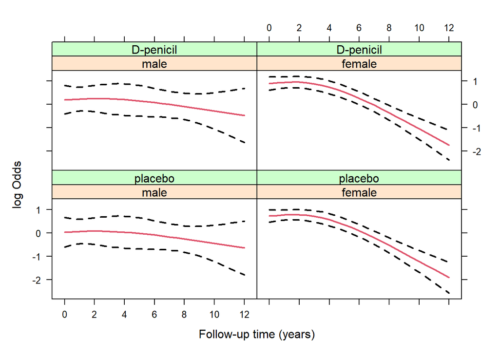

```r
xyplot(pred + low + upp ~ year | sex * drug,
       data = effectPlotData(fm_3_IntFinal, newDF, pbc2),
       lty = c(1, 2, 2), col = c(2, 1, 1), lwd = 2, type = "l",
       xlab = "Follow-up time (years)",
       ylab = "log Odds")
```

And following the plot for the probability of abnormal prothrombin time (the first line of code defines the helper function `expit()` which transform the log odds to probabilities):

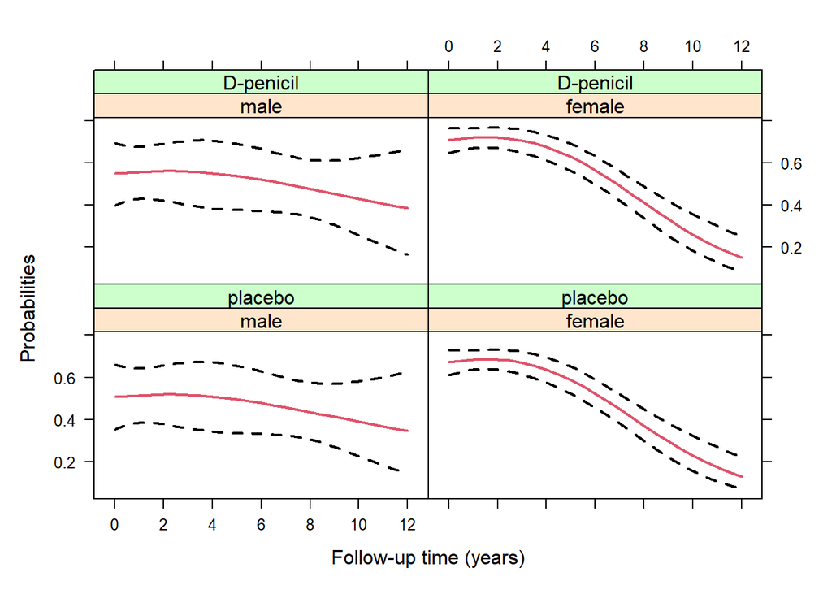

```r
expit <- function (x) exp(x) / (1 + exp(x))
xyplot(expit(pred) + expit(low) + expit(upp) ~ year | sex * drug,
       data = effectPlotData(fm_3_IntFinal, newDF, pbc2),
       lty = c(1, 2, 2), col = c(2, 1, 1), lwd = 2, type = "l",
       xlab = "Follow-up time (years)",
       ylab = "Probabilities")
```

### Question 9

To test for differences for males and females patients at different time points we will use function `rowDiff()` and the theory behind it, which we have introduced in Section 4.6:

```r
rowDiff <- function (object, newdata, orig_data, adjust.p = FALSE, ...) {
    form <- formula(object)
    namesVars <- all.vars(form)
    betas <- if (!inherits(object, "lme")) coef(object) else fixef(object)
    V <- if (inherits(object, "geeglm")) object$geese$vbeta else vcov(object)
    orig_data <- orig_data[complete.cases(orig_data[namesVars]), ]
    Terms <- delete.response(terms(form))
    mfX <- model.frame(Terms, data = orig_data)
    Terms_new <- attr(mfX, "terms")
    mfX_new <- model.frame(Terms_new, newdata, xlev = .getXlevels(Terms, mfX))
    X <- model.matrix(Terms_new, mfX_new)
    ind <- combn(nrow(X), 2)
    k <- ncol(ind)
    out <- matrix(0, k, 5)
    for (i in seq_len(k)) {
        XX <- X[ind[1, i], , drop = FALSE] - X[ind[2, i], , drop = FALSE]
        est <- drop(XX %*% betas)
        se <- sqrt(diag(XX %*% V %*% t(XX)))
        out[i, 1] <- est
        out[i, 2] <- se
        out[i, 3] <- est - 1.96 * se
        out[i, 4] <- est + 1.96 * se
        out[i, 5] <- 2 * pnorm(abs(est / se), lower.tail = FALSE)
    }
    if (k > 2 && adjust.p) {
        out[, 5] <- p.adjust(out[, 5], ...)
    }
    colnames(out) <- c("Diff", "Std.Err.", "95%low", "95%upp", "p-value")
    rownames(out) <- paste(ind[1, ], "-", ind[2, ])
    out
}
```

To use this function we first need to define the data frame with rows the corresponding combinations of the covariates we would like to test. Hence, for the time variable we choose the follow-up years 2, 6, 8, and 10, for age 49 years old, from drug D-penicillamine, and for sex males:

```r
nDF_male <- with(pbc2, expand.grid(
    year = c(2, 6, 8, 10), age = 49,
    drug = levels(drug)[2],
    sex = levels(sex)[1]
))
nDF_male
```

```
##   year age      drug  sex
## 1    2  49 D-penicil male
## 2    6  49 D-penicil male
## 3    8  49 D-penicil male
## 4   10  49 D-penicil male
```

The we the following call to `rowDiff()` we perform the pairwise comparisons:

```r
rowDiff(fm_3_IntFinal, nDF_male, pbc2)
```

```
##        Diff Std.Err. 95%low 95%upp p-value
## 1 - 2 0.163    0.211 -0.249  0.576   0.438
## 1 - 3 0.334    0.333 -0.319  0.986   0.316
## 1 - 4 0.524    0.531 -0.518  1.565   0.324
## 2 - 3 0.170    0.198 -0.218  0.558   0.389
## 2 - 4 0.360    0.433 -0.488  1.208   0.405
## 3 - 4 0.190    0.235 -0.271  0.651   0.419
```

Before going to interpret the results we should note that we have performed multiple tests and therefore we should accordingly adjust the p-values. To do that we set argument `adjust.p` of `rowDiff()` to `TRUE`, i.e.,

```r
rowDiff(fm_3_IntFinal, nDF_male, pbc2, adjust.p = TRUE)
```

```
##        Diff Std.Err. 95%low 95%upp p-value
## 1 - 2 0.163    0.211 -0.249  0.576       1
## 1 - 3 0.334    0.333 -0.319  0.986       1
## 1 - 4 0.524    0.531 -0.518  1.565       1
## 2 - 3 0.170    0.198 -0.218  0.558       1
## 2 - 4 0.360    0.433 -0.488  1.208       1
## 3 - 4 0.190    0.235 -0.271  0.651       1
```

Each row in the output of `rowDiff()` corresponds to a comparison of the corresponding rows of the data frame `nDF_male`, i.e., the first row is the comparison between year 2 and year 6, the second row between year 2 and year 8, and so on. After adjusting for multiple comparisons we do not find any significant results. We continue to perform the same pairwise comparisons for the females. First, we construct the data frame `nDF_female` accordingly:

```r
nDF_female <- with(pbc2, expand.grid(
    year = c(2, 6, 8, 10), age = 49,
    drug = levels(drug)[2],
    sex = levels(sex)[2]
))
nDF_female
```

```
##   year age      drug    sex
## 1    2  49 D-penicil female
## 2    6  49 D-penicil female
## 3    8  49 D-penicil female
## 4   10  49 D-penicil female
```

And we use it in the call to `rowDiff()`:

```r
rowDiff(fm_3_IntFinal, nDF_female, pbc2, adjust.p = TRUE)
```

```
##        Diff Std.Err. 95%low 95%upp  p-value
## 1 - 2 0.683   0.1008  0.486  0.881 4.88e-11
## 1 - 3 1.308   0.1689  0.977  1.639 5.74e-14
## 1 - 4 1.994   0.2646  1.476  2.513 2.39e-13
## 2 - 3 0.624   0.0933  0.441  0.807 6.54e-11
## 2 - 4 1.311   0.2016  0.916  1.706 1.59e-10
## 3 - 4 0.687   0.1086  0.474  0.899 2.54e-10
```

For females, and after adjusting for multiple comparisons we observe that all differences are significant.